# Heavy Metal Concentrations at Abandoned Tungsten Mines

Lilianna Broussalian

2022-11-18

## Project Motivation

Tungsten (W) became a new emerging contaminant of concern for the United States (U.S.) Environmental Protection Agency (EPA) in 2002 after multiple studies correlated elevated tungsten concentrations with adverse health effects and environmental risks(EPA 2014). Three childhood leukemia clusters appeared between 1997 and 2003 in Fallon, NV, Sierra Vista, AZ, and Grove, CA, prompting extensive testing and exposure assessments of environmental contaminants in drinking and surface water, surface soils, residential indoor dust, and air (Rubin et al. 2007; P. R. Sheppard and Witten 2003; Paul R. Sheppard et al. 2012; Dermatas et al. 2006; Larson and Dermatas 2009; Strigul, Koutsospyros, and Christodoulatos 2010; Strigul et al. 2005; Koutsospyros et al. 2006; Tuna et al. 2012a). Biological testing done by the Center for Disease Control (CDC) reported high levels of tungsten in urine (as high as 15 times the national average) from residents near Fallon, NV (CDC 2003), as well as high tungsten concentrations in trees from all three communities (P. R. Sheppard and Witten 2003). All three towns are located near anthropogenic sources of tungsten including active or inactive tungsten mines, processing operations, and/or military bases. These events prompted the National Center for Environmental Health (NCEH) and CDC to designate tungsten for further study under the National Toxicity Program (ATSDR 2005). While the events in Fallon, NV and Sierra Vista, AZ brought awareness to the threat of tungsten toxicity, to date there are no drinking water standards or regulations for the discharge of tungsten into the air, surface water, groundwater, or soils in the United States (EPA 2021).

The market for tungsten has developed quickly since its official discovery in 1783 and tungsten is now recognized as one of 50 minerals deemed “critical to U.S national security and the economy” by the Energy Act of 2020 (Nassar and Fortier 2021). Tungsten ore is used to produce tungsten alloys and tungsten carbide which have a wide range of applications including welding, high-temperature cutting/drilling technologies, aerospace industries, filaments in light bulbs, and in manufacturing of electrodes and components used in touchscreen products (EPA 2014; U.S. Geological Survey 2021; Kabata-Pendias and Mukherjee 2007). While tungsten has been used in munitions since the Second World War, production ramped up in the mid-1990s following a military initiative to go “green” by substituting toxic lead and radioactive uranium with an “environmentally friendly” alternative thought to be tungsten (EPA 2014), (Jay L. Clausen et al. 2011), (Jay L. Clausen et al. 2007), (Dermatas et al. 2006), (Bostick et al. 2018), (Koutsospyros et al. 2006). China is currently the world’s largest producer of tungsten controlling more than 80% of the world’s supply but has effectively discontinued their exports in recent years, prompting tungsten to be moved to the top of the “endangered list” due to the limited supply (BGS 2016). There have been no active U.S commercial tungsten mines in operation since 2015 (USGS n.d.), however in 1955, the U.S. boasted more than 740 operating tungsten mines (Shedd 2002) and according to USGS scientist Jeff Mauk, “the United States may have future production potential from U.S. projects that are currently in the advanced exploration stage,”(Burton and Demas 2021) . The economic importance of tungsten and the growing concern about limited supply gives an urgency to the research on the environmental fate and transport of tungsten. High concentrations of W have the potential to flow and seep into natural waters and soils from these legacy tungsten mines as well as future tungsten mines. Identifying the controls on tungsten mobility at these abandoned mines is a vital first step towards mitigation.

The purpose of this study is to identify if adsorption is the main control on W contamination mobility in surficial soils and surface water from exposed tailings and waste piles at the Boriana and Black Pearl abandoned tungsten mines, in western, Arizona. To determine whether adsorption is the main control on W mobility, we must identify controls on tungsten adsorption in this field setting. The ultimate goal of this research is to provide a framework we can build upon to predict and prevent the mobilization of tungsten contamination from anthropogenic sources in the environment.

## Fate and Transport of Tungsten

The previous and long held notion that tungsten is immobile and environmentally “green” (Kerwien 1996; Koutsospyros et al. 2006) is not supported by current research. Studies conducted at small arms firing ranges that utilized “green” ammunition found tungsten contamination in groundwater, subsurface and surficial soil, and plants Jay L. Clausen et al. (2007); Jay L. Clausen et al. (2011); A. J. Bednar et al. (2006); A. J. Bednar et al. (2009); Bostick et al. (2018); Seiler, Stollenwerk, and Garbarino (2005); Tuna et al. (2012a); Datta et al. (2017); Johannesson et al. (2013). Elevated tungsten levels attributed to nearby active mining operations have been found in soils, the crops grown in the contaminated soils in rice fields in China (Silvetti et al. 2014; Lin et al. 2014; Bob Wilson and Pyatt 2006; B. Wilson and Pyatt 2009), as well as in soils and plants near inactive mining operations in southwestern France and northwest England.

Elevated tungsten levels observed in anthropogenically contaminated surficial soils occur as two major aqueous species: metallic tungsten W(0) and oxide species W(VI) (Bostick et al. 2018; Jay L. Clausen and Korte 2009; Seiler, Stollenwerk, and Garbarino 2005; Strigul et al. 2005; Tuna et al. 2012b; Hobson et al. 2020). Bostick et al. (2018) reports that 98% of tungsten in contaminated soils from a munitions firing range is present as W(VI) after only a few years of exposure to the elements. This rapid environmental oxidation of metallic W(0) to highly soluble W(VI) species suggests W(VI) is the redox state of interest when considering transport and fate (Hobson et al. 2020; Datta et al. 2017; Gustafsson 2003). While aqueous speciation of tungstate W(VI) is complicated and geochemical properties of polymer species seem to vary from those of monomeric tungstate (Davantes et al. 2017; A. J. Bednar et al. 2006; Jay L. Clausen et al. 2011; Petruzzell and Pedron 2021; Hur and Reeder 2016), recent studies have concluded the fundamental controls on tungsten speciation include pH, concentration of tungsten, and presence of other solutes such as silica and phosphorus (Wasylenki et al. 2020; Bostick et al. 2018; Hobson et al. 2020; Datta et al. 2017; Johannesson et al. 2013; A. J. Bednar et al. 2006). The monomeric tungstate species (WO<sub>4</sub><sup>2-</sup>) observed at low concentrations and high pH (>8 pH) appear stable and dominate in solution while polymeric tungstate species observed at high concentrations and low pH (<5 pH) appear to dominate solution (Bostick et al. 2018; Johannesson et al. 2013).

## Knowledge Gaps

Previous reviewed literature from the past two decades has progressed our knowledge on the controls of tungsten mobility significantly however the question of applicability of these results to natural field settings remains a challenge . Tungsten concentrations reported for non-polluted soils in the U.S range from 0.5 to 5.0 mg/kg, from 0.01 to 0.05 µg/L in non-polluted stream waters, and from 100 to 200 mg/kg in soils surrounding tungsten ore-processing plants (Kabata-Pendias and Mukherjee 2007). Concentrations in the majority of these experiments are 1 to 3 orders or magnitude higher than what would be typically observed in a field setting for non-polluted soils and 8 orders of magnitude higher for surficial water (1420 mg/kg (Jay L. Clausen and Korte 2009), 515 mg/L & 700 mg/kg (Strigul et al. 2005), 7080 mg/kg (A. J. Bednar et al. 2009), 50 mg/kg (Johannesson et al. 2013)). Simple experiments to determine the aqueous speciation and sorption affinities of tungsten in a laboratory at field relative tungsten concentrations so far do not address the effects of continual water flow or other variability introduced in natural environmental settings (Wasylenki et al. 2020). Field testing completed at munitions testing facilities are not only representative of extreme examples of concentrated contamination in soils (up to 5100 mg/kg [W]) but also only represent one anthropogenic source of tungsten contamination (Jay L. Clausen et al. 2011; A. J. Bednar et al. 2009; Bostick et al. 2018). Methods and procedures for the collection, preparation, and analysis of tungsten in the environment are still under development by U.S federal regulatory agencies (EPA United States Environmental Protection Agency 2017). As such, the effectiveness and reproducibility of results from various laboratory testing procedures is another challenge. Tungsten can be measured using ICP-MS, and multiple studies utilize modified EPA acid digestion methods to extract bulk concentrations of tungsten from soil and water (B. Wilson and Pyatt 2009; Hobson et al. 2020; Jay L. Clausen et al. 2007; Zimmerman and Weindorf 2010; A. J. Bednar et al. 2009; Cutler and Stillings 2011; Dold 2003; Assam and Stillings 2007; Joseph Taggart and Editor, n.d.; Cao et al. 2020; Li et al. 2019; Wenzel et al. 2001; Gómez-Álvarez et al. 2015; Violante et al. 2010; Tessier, Campbell, and Bisson 1979). In addition to the variations of acid digestions for bulk extraction, many studies include variations of sequential extraction procedures (SEP) which aim to test the controls of W mobility using the relationship between mobility and W fractionation (Bostick et al. 2018; Hobson et al. 2020; Zimmerman and Weindorf 2010; Cutler and Stillings 2011; Joseph Taggart and Editor, n.d.; Li et al. 2019; Wenzel et al. 2001; Tessier, Campbell, and Bisson 1979; Gaudino et al. 2007; Kalyvas, Gasparatos, and Massas 2018; Petruzzelli and Pedron 2017; Gómez Ariza et al. 2000; A. J. Bednar et al. 2010). Most SEPs follow a similar fractionation order generally cited from Tessier et al. (1979) beginning with exchangeable, then carbonate bound, followed by manganese and iron oxide bound, organic matter, and finally residual. However, many studies publish drastically different and often conflicting results even when utilizing the same SEP (Li et al. 2019; Cao et al. 2020; Gómez Ariza et al. 2000; Alan and Kara 2019; Hall, Jefferson, and Michel 1988; Claff et al. 2010; Violante et al. 2010; Miller, Martens, and Zelazny 1986; Mesko et al. 2013).

## Dataset

The commonalities between the Boriana and Black Pearl mines make them comparable study sites and will potentially yield corroborating results. Both the Boriana and Black Pearl mines operated c. 1914-1956 with a majority of mining operations occurring below ground and milling and processing operations above ground. These mines produced ore with an average recovery percentage of wolframite (WO<sub>3</sub>) at 70.0% (Dale 1961; Mines 1991; Stein, Hannah, and America. 1990). At present, mine waste and tailings piles are barren and exposed with no coverings or repository closure methods in place. Both mine localities are characterized as semi-arid regions averaging less than 17 inches of precipitation annually and include ephemeral streams as drainage channels that discharge into the intermittent streams of Mackenzie Creek (Boriana) and Boulder Creek (Black Pearl). I hypothesize these drainage channels act as preferential pathways for tungsten and other heavy metal contaminants to mobilize in the dissolved phase via surface runoff and precipitation events to downgradient streams and surrounding watersheds. Surficial soil and water samples were collected in October 2021 and March 2022 (Maps 1 & 2) from the Black Pearl and Boriana Mines and pseudo bulk soil analysis was completed on a subset of soil samples from the Black Pearl Mine using an inductively coupled mass spectrometer (ICP-MS) in April and June 2022. The dataset used for visualization in this report comprises of a subset of these samples.

[interactive chart not shown]

Map 1. Sample location map of the Black Pearl Mine.

[interactive chart not shown]

Map 2. Sample location map of the Boriana Mine.

## Methodology

Fieldwork and Sample Collection Fieldwork consists of the collection of surficial soil samples at the Boriana and Black Pearl Mines from the source points (tailings and waste piles), upgradient from source points, downgradient from the source points within the drainage channels at 20-25m intervals to the intermittent streams of Boulder and Mackenzie Creek, in the intermittent streams of Boulder and Mackenzie Creek above, between, and below the entry points of drainage channels, and downgradient from source points outside the drainage channels. Water samples and water quality measurements using a YSI multi-parameter probe will be collected from Boulder and Mackenzie Creek above, between, and below the entry points of drainage channels. Soil samples are collected in air-tight plastic bags while water samples are collected in 15mL plastic centrifuge tubes and stored in a cool dark place. To prevent cross contamination in the field, sample gloves are switched out between each sample. Following field collection, grain size analysis is done on the soil samples using plastic #40 and #200 sieves to determine if there is a relationship between grain size and W adsorption during transport.

Laboratory Analysis Laboratory work includes pseudo bulk concentration analysis via acid digestion according to modified US EPA Method 3050b as described in Bednar et al. (A. J. Bednar et al. 2010, 2009) and the SEP described in Hobson et al. (Hobson et al. 2020). To complete pseudo bulk analysis, soil samples will be digested in concentrated nitric and phosphoric acid with heat and then in hydrogen peroxide to leach secondary precipitates deposited on the sediment grains during runoff, filtered through 0.2µm polypropylene syringe filters, dried, then dissolved in 2% nitric and trace hydrofluoric acid (HF), diluted, and analyzed using an Inductively Coupled Plasma Mass Spectrometer (ICP-MS) to determine W, Fe, and Mn concentrations. In conjunction with W, Fe, Mn, Ni, Cu, Zn, Mo, Pb, and U may also be analyzed in select samples to determine any correlations between other heavy metals and W adsorption from these mine tailings. Water samples are filtered (same filters as soil samples), diluted with 2% nitric acid and trace HF, and analyzed using on the ICP-MS for W, Fe, and Mn concentrations. Bulk soil concentrations are extracted using the following calculation.
$$\frac{MetalAmount(ng)}{BulkSoil(g)} = ICP-MS(ppb)
* \frac{QuadSample}{D1SampleAliquot} * \frac{Digested Sample}{Bulk
Sample}$$

## Data Analysis

### Correlation of heavy metal concentrations and spatial visualization

Using the results from the April and June 2022 ICP-MS run, we can see some metals correlate with each other better than others. Figure one shows that when we compare W concentrations with all other heavy metals, Mo and Fe have decent correlation coefficients while U and Cu don’t seem to be correlated with W at all. Similarly, looking at heavy metals as a function of Fe and Mn concentrations (Figures 2 and 3) we see stronger correlations between Fe and Mo, and Mn and Zn compared to any other metals. We can also visualize this data spatially at the Black Pearl Mine in Maps 3, 4, and 5.

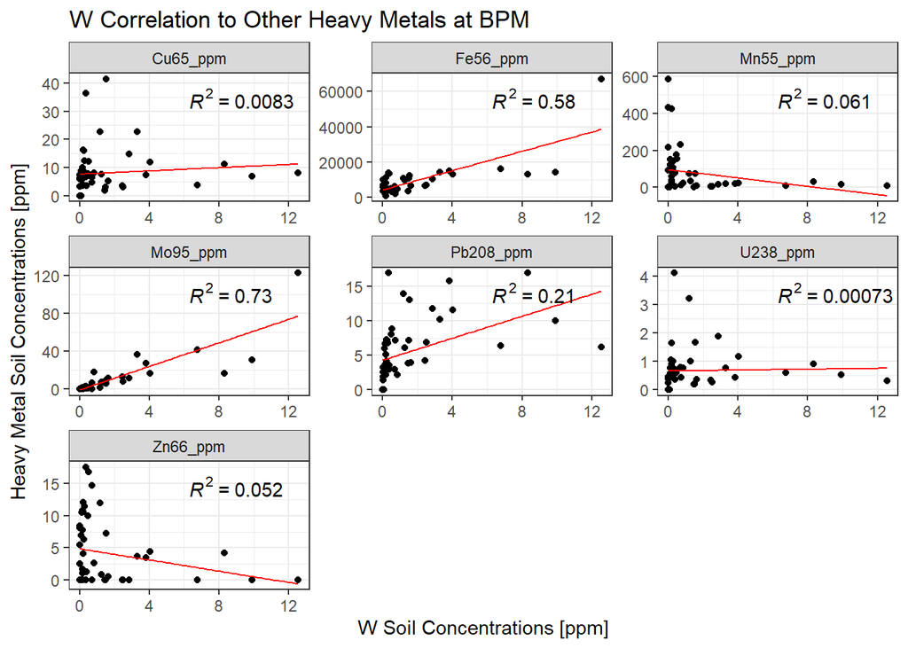

Figure 1. Concentration plots of W vs all other heavy metals at Black Pearl Mine.

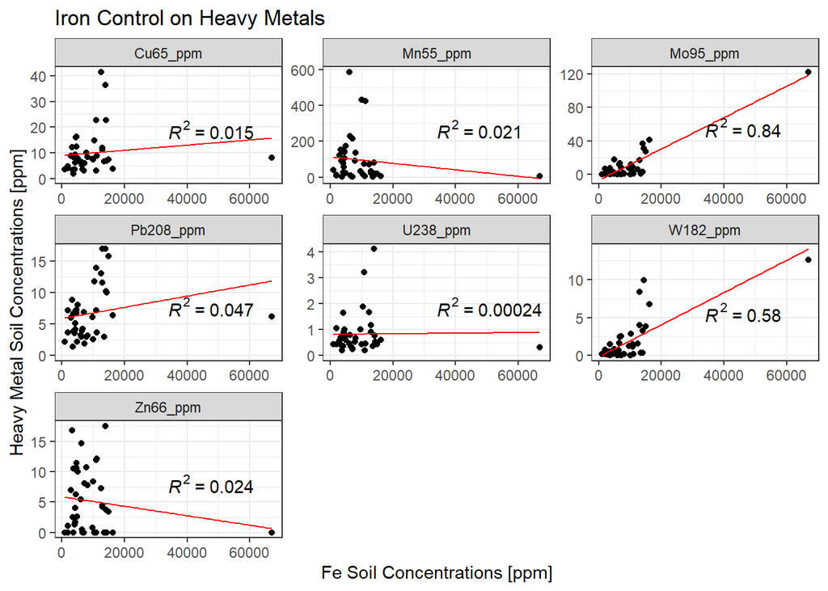

Figure 2. Concentration plots of Fe vs all other heavy metals at Black Pearl Mine.

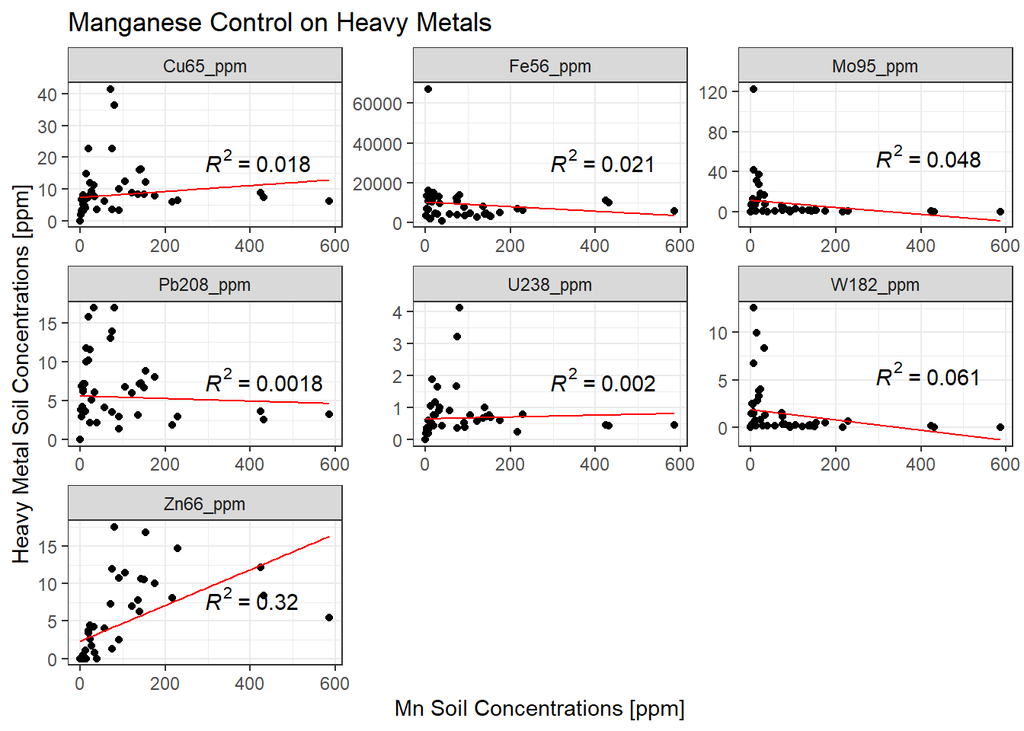

Figure 3. Concentration plots of Mn vs all other heavy metals at Black Pearl Mine.

[interactive chart not shown]

Map 3. Heavy metal concentrations at the Black Pearl Mine.

[interactive chart not shown]

Map 4. Ratio of heavy metals to Fe concentrations at the Black Pearl Mine.

[interactive chart not shown]

Map 5. Ratio of heavy metals to Mn concentrations at the Black Pearl Mine.

### Principal Component Analysis- Black Pearl Mine Soil Samples

Finally, we can statistically compute these relationships using principal component analysis (PCA). In figure 4, we can see there is a clear and positively correlated relationship between Fe, W, and Mo and they have the strongest effect on PC1 while Mn is inversely correlated and strongly effects PC1. I also feel confident interpreting from the PCA that Pb, Cu, and U are correlated with a stronger effect on PC2. There also seems to be some minor correlation with Zn and Mn which we also observe in Figure 3.

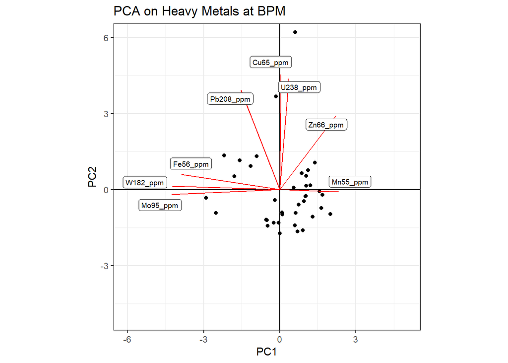

Figure 4. PCA of soil concentrations at the Black Pearl Mine.

## Conclusion

Thus far, I think the results I have trend with what we expect to see geochemically at the Black Pearl Mine. While there are huge amounts of error in this dataset, the largest source being my own initial laboratory work, I have made tremendous progress developing my laboratory procedures the past few months that should significantly cut down on that error. After I have more completed laboratory testing on more samples however, I believe PCA as well as the spatial visualization will be extremely useful tools for my research.

## References

Alan, Mesut, and Derya Kara. 2019. “Comparison of a new sequential extraction method and the BCR sequential extraction method for mobility assessment of elements around boron mines in Turkey.” *Talanta* 194 (March): 189–98. https://doi.org/10.1016/J.TALANTA.2018.10.030.

Assam, Jason, and Lisa L Stillings. 2007. “Tungstate adsorption on ferrihydrite: Extraction of equilibrium adsorption constants, and application to the shallow and intermediate, basin-fill aquifers in Fallon, NV.” PhD thesis.

ATSDR. 2005. “TOXICOLOGICAL PROFILE FOR TUNGSTEN.”

Bednar, A J, J E Mirecki, L S Inouye, L E Winfield, S L Larson, and D B Ringelberg. 2006. “Speciation and geochemistry of tungsten in soil,” 6.

Bednar, A. J., R. E. Boyd, W. T. Jones, C. J. McGrath, D. R. Johnson, M. A. Chappell, and D. B. Ringelberg. 2009. “Investigations of tungsten mobility in soil using column tests.” *Chemosphere* 75 (8): 1049–56. https://doi.org/10.1016/j.chemosphere.2009.01.039.

Bednar, A. J., W. T. Jones, M. A. Chappell, D. R. Johnson, and D. B. Ringelberg. 2010. “A modified acid digestion procedure for extraction of tungsten from soil.” *Talanta* 80 (3): 1257–63. https://doi.org/10.1016/J.TALANTA.2009.09.017.

BGS. 2016. “World Mineral Production 2016-2020.”

Bostick, Benjamín C, Jing Sun, Joshua D Landis, and Jay L Clausen. 2018. “Tungsten Speciation and Solubility in Munitions-Impacted Soils.” *Environmental Science and Technology* 52 (3): 1045–53. https://doi.org/10.1021/acs.est.7b05406.

Burton, Jason, and Alex Demas. 2021. “USGS Updates Mineral Database with Tungsten Deposits in the United States | U.S. Geological Survey.” https://www.usgs.gov/news/technical-announcement/usgs-updates-mineral-database-tungsten-deposits-united-states.

Cao, Caifang, Xiaochen Qiu, Yuhu Li, Liang Yang, Zhensheng Pang, and Zhuangzhuang Yuan. 2020. “Study on leaching behaviour of tungstates in acid solution containing phosphoric acid.” *Hydrometallurgy* 197 (November): 105392. https://doi.org/10.1016/J.HYDROMET.2020.105392.

CDC. 2003. “Cross-Sectional Exposure Assessment of Environmental Contaminants in Churchill County, Nevada -Final Report- February 6, 2003.” Atlanta, GA: Center for Disease Control; Prevention. http://www.cdc.gov/nceh/hsb.

Claff, Salirian R., Leigh A. Sullivan, Edward D. Burton, and Richard T. Bush. 2010. “A sequential extraction procedure for acid sulfate soils: Partitioning of iron.” *Geoderma* 155 (3-4): 224–30. https://doi.org/10.1016/J.GEODERMA.2009.12.002.

Clausen, Jay L, Benjamin C Bostick, Anthony Bednar, Jing Sun, and Joshua D Landis. 2011. “Tungsten Speciation in Firing Range Soils Engineer Research and Development Center,” no. January.

Clausen, Jay L., and Nic Korte. 2009. “Environmental fate of tungsten from military use.” *Science of the Total Environment* 407 (8): 2887–93. https://doi.org/10.1016/j.scitotenv.2009.01.029.

Clausen, Jay L, Susan Taylor, Steven L Larson, J Anthony, Michael Ketterer, Chris S Griggs, and Dennis J Lambert. 2007. “Fate and Transport of Tungsten at Camp Edwards Small Arms Ranges Engineer Research and Development Center,” no. August.

Cutler, Nicole K, and Lisa L Stillings. 2011. “The geochemistry of groundwater and sediments governing tungsten concentration in the basin-fill aquifers Fallon , Nevada A thesis submitted in partial fulfillment of the requirements for the degree of Master of Science in Hydrology By Thesis Advisor.” PhD thesis.

Dale, V B. 1961. “TUNGSTEN DEPOSITS OF GILA, YAVAPAI, AND MOHAVE COUNTIES, ARIZ.” *US Department of the Interior, Bureau of Mines*.

Datta, Saugata, Sara E. Vero, Ganga M. Hettiarachchi, and Karen Johannesson. 2017. “Tungsten Contamination of Soils and Sediments: Current State of Science.” *Current Pollution Reports* 3 (1): 55–64. https://doi.org/10.1007/s40726-016-0046-0.

Davantes, A., D. Costa, B. Sallman, S. Rakshit, and G. Lefevre. 2017. “Surface polymerization of Mo(VI) and W(VI) anions on hematite revealed by in situ infrared spectroscopy and DFT+U theoretical study.” *Journal of Physical Chemistry C* 121 (1): 324–32. https://doi.org/10.1021/ACS.JPCC.6B09721/SUPPL_FILE/JP6B09721_SI_001.PDF.

Dermatas, Dimitris, Xinde Cao, Valentina Tsaneva, Gang Shen, and Dennis G. Grubb. 2006. “Fate and behavior of metal(loid) contaminants in an organic matter-rich shooting range soil: Implications for remediation.” *Water, Air, and Soil Pollution: Focus* 6 (1-2): 143–55. https://doi.org/10.1007/s11267-005-9003-4.

Dold, Bernhard. 2003. “Speciation of the most soluble phases in a sequential extraction procedure adapted for geochemical studies of copper sulfide mine waste.” *Journal of Geochemical Exploration* 80 (1): 55–68. https://doi.org/10.1016/S0375-6742(03)00182-1.

EPA. 2014. “Tungsten - Technical Fact Sheet.” January. https://www.epa.gov/sites/production/files/2014-03/documents/ffrrofactsheet{\_}contaminant{\_}tungsten{\_}january2014{\_}final.pdf.

———. 2021. “Federal Register :: Drinking Water Contaminant Candidate List 5-Draft.” https://www.federalregister.gov/documents/2021/07/19/2021-15121/drinking-water-contaminant-candidate-list-5-draft.

EPA United States Environmental Protection Agency. 2017. “Technical Fact Sheet - Tungsten EPA 505-F-17-004,” no. November.

Gaudino, Stefania, Chiara Galas, Maria Belli, Sabrina Barbizzi, Paolo De Zorzi, Radojko Jaćimović, Zvonka Jeran, Alessandra Pati, and Umberto Sansone. 2007. “The role of different soil sample digestion methods on trace elements analysis: A comparison of ICP-MS and INAA measurement results.” *Accreditation and Quality Assurance* 12 (2): 84–93. https://doi.org/10.1007/S00769-006-0238-1/TABLES/8.

Gómez Ariza, J. L., I. Giráldez, D. Sánchez-Rodas, and E. Morales. 2000. “Selectivity assessment of a sequential extraction procedure for metal mobility characterization using model phases.” *Talanta* 52 (3): 545–54. https://doi.org/10.1016/S0039-9140(00)00410-0.

Gómez-Álvarez, Agustín, Jesús L. Valenzuela-García, Salvador Aguayo-Salinas, Diana Meza-Figueroa, Jorge Ramírez-Hernández, and Gabriel Ochoa-Ortega. 2015. “Chemical partitioning of sediment contamination by heavy metals in the San Pedro River, Sonora, Mexico.” *Http://Www.tandfonline.com/Action/journalInformation?show=aimsScope&journalCode=tcsb20* 19 (1): 25–35. https://doi.org/10.3184/095422907X198013.

Gustafsson, Jon Petter. 2003. “Modelling molybdate and tungstate adsorption to ferrihydrite.” *Chemical Geology* 200 (1-2): 105–15. https://doi.org/10.1016/S0009-2541(03)00161-X.

Hall, G. E. M., C. W. Jefferson, and F. A. Michel. 1988. “Determination of W and Mo in natural spring waters by ICP-AES (Inductively Coupled Plasma Atomic Emission Spectrometry) and ICP-MS (Inductively Coupled Plasma Mass Spectrometry): Application to South Nahanni river area, N.W.T., Canada.” *Journal of Geochemical Exploration* 30 (1-3): 63–84. https://doi.org/10.1016/0375-6742(88)90050-7.

Hobson, Chad, Harshad V. Kulkarni, Karen H. Johannesson, Anthony Bednar, Ryan Tappero, T. Jade Mohajerin, Paul R. Sheppard, Mark L. Witten, Ganga M. Hettiarachchi, and Saugata Datta. 2020. “Origin of tungsten and geochemical controls on its occurrence and mobilization in shallow sediments from Fallon, Nevada, USA.” *Chemosphere* 260 (December): 127577. https://doi.org/10.1016/j.chemosphere.2020.127577.

Hur, Hyuck, and Richard J. Reeder. 2016. “Tungstate sorption mechanisms on boehmite: Systematic uptake studies and X-ray absorption spectroscopy analysis.” *Journal of Colloid and Interface Science* 461 (January): 249–60. https://doi.org/10.1016/J.JCIS.2015.09.011.

Johannesson, Karen H., Heeral B. Dave, T. Jade Mohajerin, and Saugata Datta. 2013. “Controls on tungsten concentrations in groundwater flow systems: The role of adsorption, aquifer sediment Fe(III) oxide/oxyhydroxide content, and thiotungstate formation.” *Chemical Geology* 351 (August): 76–94. https://doi.org/10.1016/J.CHEMGEO.2013.05.002.

Joseph Taggart, by E, and Jr Editor. n.d. “Analytical methods for chemical analysis of geologic and other materials, U.S. Geological Survey.”

Kabata-Pendias, Alina, and Arun B. Mukherjee. 2007. “Trace elements from soil to human.” *Trace Elements from Soil to Human*, 1–550. https://doi.org/10.1007/978-3-540-32714-1.

Kalyvas, Georgios, Dionisios Gasparatos, and Ioannis Massas. 2018. “A critical assessment on arsenic partitioning in mine-affected soils by using two sequential extraction protocols.” *Https://Doi.org/10.1080/03650340.2018.1443443* 64 (11): 1549–63. https://doi.org/10.1080/03650340.2018.1443443.

Kerwien, Stacey Clark. 1996. “TOXICITY OF TUNGSTEN, MOLYBDENUM, AND TANTALUM AND THE ENVIRONMENTAL AND OCCUPATIONAL LAWS ASSOCIATED WITH THEIR MANUFACTURE, USE, AND DISPOSAL mm of 7 )H0 qp&Mff USffSOIäl’l.”

Koutsospyros, A., W. Braida, C. Christodoulatos, D. Dermatas, and N. Strigul. 2006. “A review of tungsten: From environmental obscurity to scrutiny.” Elsevier. https://doi.org/10.1016/j.jhazmat.2005.11.007.

Larson, Steven L., and Dimitris Dermatas. 2009. “Tungsten in the geo-environment.” *Land Contamination and Reclamation* 17 (1): 1–6. https://doi.org/10.2462/09670513.936.

Li, Ruiping, Wenjie Wang, Shiliang Wang, Chunye Lin, Xiangyi Wang, Lingchuan Meng, and Xianlong Yuan. 2019. “Comparison of two sequential extraction procedures for tungsten fractionation in the tungsten mining soils.” *RSC Advances* 9 (61): 35456–62. https://doi.org/10.1039/C9RA07158J.

Lin, Chunye, Ruiping Li, Hongguang Cheng, Jing Wang, and Xiao Shao. 2014. “Tungsten Distribution in Soil and Rice in the Vicinity of the World’s Largest and Longest-Operating Tungsten Mine in China.” *PLOS ONE* 9 (3): e91981. https://doi.org/10.1371/JOURNAL.PONE.0091981.

Mesko, Márcia F., Carla A. Hartwig, Cezar A. Bizzi, Edson I. Müller, Fábio A. Duarte, and Paola A. Mello. 2013. “Separation techniques for elemental speciation in soil, sediments, and environmental samples.” *Speciation Studies in Soil, Sediment and Environmental Samples*, January, 202–41. https://doi.org/10.1201/B15501.

Miller, W. P, D. C Martens, and L. W Zelazny. 1986. “Effect of Sequence in Extraction of Trace Metals from Soils.” *Soil Science Society of America* 50 (3): 598–601.

Mines, U. S Bureau of. 1991. “Black Pearl (MRDS #10161782) W.” https://mrdata.usgs.gov/mrds/show-mrds.php?dep{\_}id=10161782.

Nassar, Nedal T., and Steven M. Fortier. 2021. “Methodology and technical input for the 2021 review and revision of the U.S. Critical Minerals List.” *Open-File Report*. https://doi.org/10.3133/OFR20211045.

Petruzzell, Gianniantonio, and Francesca Pedron. 2021. “The dynamics of tungsten in soil: An overview.” *Environments - MDPI* 8 (7). https://doi.org/10.3390/environments8070066.

Petruzzelli, Gianniantonio, and Francesca Pedron. 2017. “Tungstate adsorption onto Italian soils with different characteristics.” *Environmental Monitoring and Assessment* 189 (8): 1–10. https://doi.org/10.1007/S10661-017-6088-Y/TABLES/4.

Rubin, Carol S., Adrianne K. Holmes, Martin G. Belson, Robert L. Jones, W. Dana Flanders, Stephanie M. Kieszak, John Osterloh, et al. 2007. “Investigating childhood leukemia in Churchill County, Nevada.” *Environmental Health Perspectives* 115 (1): 151–57. https://doi.org/10.1289/EHP.9022.

Seiler, Ralph L, Kenneth G Stollenwerk, and John R Garbarino. 2005. “Factors controlling tungsten concentrations in ground water, Carson Desert, Nevada.” *Applied Geochemistry* 20 (2): 423–41. https://doi.org/10.1016/j.apgeochem.2004.09.002.

Shedd, Kirn B. 2002. “The U.S. Tungsten Market 3IUSGS.” *U.S.G.S*.

Sheppard, P R, and M L Witten. 2003. *Dendrochemistry of urban trees in an enviromental exposure analysis of childhood leukemia cluster areas*. https://www.researchgate.net/publication/253790587{\_}Dendrochemistry{\_}of{\_}Urban{\_}Trees{\_}in{\_}an{\_}Environmental{\_}Exposure{\_}Analysis{\_}of{\_}Childhood{\_}Leukemia{\_}Cluster{\_}Areas.

Sheppard, Paul R., Brian J. Bierman, Kent Rhodes, Gary Ridenour, and Mark L. Witten. 2012. “Comparison of size and geography of airborne tungsten particles in Fallon, Nevada, and sweet home, Oregon, with implications for public health.” *Journal of Environmental and Public Health* 2012. https://doi.org/10.1155/2012/509458.

Silvetti, Margherita, Paola Castaldi, Peter E. Holm, Salvatore Deiana, and Enzo Lombi. 2014. “Leachability, bioaccessibility and plant availability of trace elements in contaminated soils treated with industrial by-products and subjected to oxidative/reductive conditions.” *Geoderma* 214-215 (February): 204–12. https://doi.org/10.1016/J.GEODERMA.2013.09.010.

Stein, Holly J, Judith L Hannah, and Geological Society of America. 1990. *Ore-bearing granite systems : petrogenesis and mineralizing processes*. https://books.google.com/books?hl=en{\&}lr={\&}id=muI0tA7{\_}nhsC{\&}oi=fnd{\&}pg=PA221{\&}dq=Schmitz,+Christopher,+1987,+Geology+of+the+Black+Pearl+mine+area,+Yavapai+County,+Arizona:+Tempe,+Arizona+State+University,+M.S.+thesis,+154+p.{\&}ots=PeeDeE3XZE{\&}sig=HUZPIGqsYPpsIICG.

Strigul, Nikolay, Agamemnon Koutsospyros, Per Arienti, Christos Christodoulatos, Dimitris Dermatas, and Washington Braida. 2005. “Effects of tungsten on environmental systems.” *Chemosphere* 61 (2): 248–58. https://doi.org/10.1016/j.chemosphere.2005.01.083.

Strigul, Nikolay, Agamemnon Koutsospyros, and Christos Christodoulatos. 2010. “Tungsten speciation and toxicity: Acute toxicity of mono- and poly-tungstates to fish.” *Ecotoxicology and Environmental Safety* 73 (2): 164–71. https://doi.org/10.1016/J.ECOENV.2009.08.016.

Tessier, A., P. G. C. Campbell, and M. Bisson. 1979. “Sequential Extraction Procedure for the Speciation of Particulate Trace Metals.” *Analytical Chemistry* 51 (7): 844–51. https://doi.org/10.1021/AC50043A017/ASSET/AC50043A017.FP.PNG_V03.

Tuna, Gulsah Sen, Washington Braida, Adebayo Ogundipe, and David Strickland. 2012a. “Assessing tungsten transport in the vadose zone: From dissolution studies to soil columns.” *Chemosphere* 86 (10): 1001–7. https://doi.org/10.1016/j.chemosphere.2011.11.036.

———. 2012b. “Assessing tungsten transport in the vadose zone: From dissolution studies to soil columns.” *Chemosphere* 86 (10): 1001–7. https://doi.org/10.1016/J.CHEMOSPHERE.2011.11.036.

U.S. Geological Survey. 2021. *Mineral Commodity Summaries 2021 : Sand and Gravel (Industrial)*. https://doi.org/10.3133/MCS2021.

USGS. n.d. “USGS Updates Mineral Database with Tungsten Deposits in the United States.” Accessed December 26, 2021. https://www.usgs.gov/news/technical-announcement/usgs-updates-mineral-database-tungsten-deposits-united-states?qt-news{\_}science{\_}products=1{\#}qt-news{\_}science{\_}products https://www.usgs.gov/news/usgs-updates-mineral-database-tungsten-deposits-united-states?qt-n.

Violante, A., V. Cozzolino, L. Perelomov, A. G. Caporale, and M. Pigna. 2010. “Mobility and bioavailability of heavy metals and metalloids in soil environments.” *Journal of Soil Science and Plant Nutrition* 10 (3): 268–92. https://doi.org/10.4067/S0718-95162010000100005.

Wasylenki, Laura E., Augustus T. Schaefer, Piyali Chanda, and Jason C. Farmer. 2020. “Differential behavior of tungsten stable isotopes during sorption to Fe versus Mn oxyhydroxides at low ionic strength.” *Chemical Geology* 558 (December): 119836. https://doi.org/10.1016/j.chemgeo.2020.119836.

Wenzel, Walter W., Natalie Kirchbaumer, Thomas Prohaska, Gerhard Stingeder, Enzo Lombi, and Domy C. Adriano. 2001. “Arsenic fractionation in soils using an improved sequential extraction procedure.” *Analytica Chimica Acta* 436 (2): 309–23. https://doi.org/10.1016/S0003-2670(01)00924-2.

Wilson, Bob, and F. Brian Pyatt. 2006. “Bio-availability of tungsten in the vicinity of an abandoned mine in the English Lake District and some potential health implications.” *Science of The Total Environment* 370 (2-3): 401–8. https://doi.org/10.1016/J.SCITOTENV.2006.07.026.

Wilson, B., and FB. Pyatt. 2009. “Bioavailability of tungsten and associated metals in calcareous soils in the vicinity of an ancient metalliferous mine in the Corbières area, southwestern France.” *Toxicol Environ Health A.* 72 (13): 807–16. https://doi.org/10.1080/15287390902800389.

Zimmerman, Amanda Jo, and David C. Weindorf. 2010. “Heavy Metal and Trace Metal Analysis in Soil by Sequential Extraction: A Review of Procedures.” *International Journal of Analytical Chemistry* 2010: 1–7. https://doi.org/10.1155/2010/387803.